# ai-ca4

```python
import pandas as pd
import numpy as np
import matplotlib.pyplot as plt
import seaborn as sns
from collections import Counter
import sklearn
from sklearn.preprocessing import OneHotEncoder
import random
from sklearn.neighbors import KNeighborsRegressor
from sklearn.linear_model import LinearRegression
from sklearn.model_selection import train_test_split
from sklearn.tree import DecisionTreeClassifier, DecisionTreeRegressor
from sklearn import metrics
sns.set_style("darkgrid")
```

```python
train_df = pd.read_csv('train.csv')
train_df.head()
```

|  | Id | MSSubClass | MSZoning | LotFrontage | LotArea | Street | Alley | LotShape | LandContour | Utilities | ... | PoolArea | PoolQC | Fence | MiscFeature | MiscVal | MoSold | YrSold | SaleType | SaleCondition | SalePrice |
| --- | --- | --- | --- | --- | --- | --- | --- | --- | --- | --- | --- | --- | --- | --- | --- | --- | --- | --- | --- | --- | --- |
| 0 | 1 | 60 | RL | 65.0 | 8450 | Pave | NaN | Reg | Lvl | AllPub | ... | 0 | NaN | NaN | NaN | 0 | 2 | 2008 | WD | Normal | 208500 |
| 1 | 2 | 20 | RL | 80.0 | 9600 | Pave | NaN | Reg | Lvl | AllPub | ... | 0 | NaN | NaN | NaN | 0 | 5 | 2007 | WD | Normal | 181500 |
| 2 | 3 | 60 | RL | 68.0 | 11250 | Pave | NaN | IR1 | Lvl | AllPub | ... | 0 | NaN | NaN | NaN | 0 | 9 | 2008 | WD | Normal | 223500 |
| 3 | 4 | 70 | RL | 60.0 | 9550 | Pave | NaN | IR1 | Lvl | AllPub | ... | 0 | NaN | NaN | NaN | 0 | 2 | 2006 | WD | Abnorml | 140000 |
| 4 | 5 | 60 | RL | 84.0 | 14260 | Pave | NaN | IR1 | Lvl | AllPub | ... | 0 | NaN | NaN | NaN | 0 | 12 | 2008 | WD | Normal | 250000 |

5 rows × 81 columns

# Phase 0:

## -- First section:

```python
train_df.info()
train_df.describe()
```

```
<class 'pandas.core.frame.DataFrame'>
RangeIndex: 1460 entries, 0 to 1459
Data columns (total 81 columns):
 #   Column         Non-Null Count  Dtype
---  ------         --------------  -----
 0   Id             1460 non-null   int64
 1   MSSubClass     1460 non-null   int64
 2   MSZoning       1460 non-null   object
 3   LotFrontage    1201 non-null   float64
 4   LotArea        1460 non-null   int64
 5   Street         1460 non-null   object
 6   Alley          91 non-null     object
 7   LotShape       1460 non-null   object
 8   LandContour    1460 non-null   object
 9   Utilities      1460 non-null   object
```

[output cut: 73 more lines]

|  | Id | MSSubClass | LotFrontage | LotArea | OverallQual | OverallCond | YearBuilt | YearRemodAdd | MasVnrArea | BsmtFinSF1 | ... | WoodDeckSF | OpenPorchSF | EnclosedPorch | 3SsnPorch | ScreenPorch | PoolArea | MiscVal | MoSold | YrSold | SalePrice |
| --- | --- | --- | --- | --- | --- | --- | --- | --- | --- | --- | --- | --- | --- | --- | --- | --- | --- | --- | --- | --- | --- |
| count | 1460.000000 | 1460.000000 | 1201.000000 | 1460.000000 | 1460.000000 | 1460.000000 | 1460.000000 | 1460.000000 | 1452.000000 | 1460.000000 | ... | 1460.000000 | 1460.000000 | 1460.000000 | 1460.000000 | 1460.000000 | 1460.000000 | 1460.000000 | 1460.000000 | 1460.000000 | 1460.000000 |
| mean | 730.500000 | 56.897260 | 70.049958 | 10516.828082 | 6.099315 | 5.575342 | 1971.267808 | 1984.865753 | 103.685262 | 443.639726 | ... | 94.244521 | 46.660274 | 21.954110 | 3.409589 | 15.060959 | 2.758904 | 43.489041 | 6.321918 | 2007.815753 | 180921.195890 |
| std | 421.610009 | 42.300571 | 24.284752 | 9981.264932 | 1.382997 | 1.112799 | 30.202904 | 20.645407 | 181.066207 | 456.098091 | ... | 125.338794 | 66.256028 | 61.119149 | 29.317331 | 55.757415 | 40.177307 | 496.123024 | 2.703626 | 1.328095 | 79442.502883 |
| min | 1.000000 | 20.000000 | 21.000000 | 1300.000000 | 1.000000 | 1.000000 | 1872.000000 | 1950.000000 | 0.000000 | 0.000000 | ... | 0.000000 | 0.000000 | 0.000000 | 0.000000 | 0.000000 | 0.000000 | 0.000000 | 1.000000 | 2006.000000 | 34900.000000 |
| 25% | 365.750000 | 20.000000 | 59.000000 | 7553.500000 | 5.000000 | 5.000000 | 1954.000000 | 1967.000000 | 0.000000 | 0.000000 | ... | 0.000000 | 0.000000 | 0.000000 | 0.000000 | 0.000000 | 0.000000 | 0.000000 | 5.000000 | 2007.000000 | 129975.000000 |
| 50% | 730.500000 | 50.000000 | 69.000000 | 9478.500000 | 6.000000 | 5.000000 | 1973.000000 | 1994.000000 | 0.000000 | 383.500000 | ... | 0.000000 | 25.000000 | 0.000000 | 0.000000 | 0.000000 | 0.000000 | 0.000000 | 6.000000 | 2008.000000 | 163000.000000 |
| 75% | 1095.250000 | 70.000000 | 80.000000 | 11601.500000 | 7.000000 | 6.000000 | 2000.000000 | 2004.000000 | 166.000000 | 712.250000 | ... | 168.000000 | 68.000000 | 0.000000 | 0.000000 | 0.000000 | 0.000000 | 0.000000 | 8.000000 | 2009.000000 | 214000.000000 |
| max | 1460.000000 | 190.000000 | 313.000000 | 215245.000000 | 10.000000 | 9.000000 | 2010.000000 | 2010.000000 | 1600.000000 | 5644.000000 | ... | 857.000000 | 547.000000 | 552.000000 | 508.000000 | 480.000000 | 738.000000 | 15500.000000 | 12.000000 | 2010.000000 | 755000.000000 |

8 rows × 38 columns

## -- Second section: sorted in descending order.

```python
a = train_df.isnull().sum() * 100 / len(train_df)
a.sort_values(ascending=False)
```

```
PoolQC           99.520548
MiscFeature      96.301370
Alley            93.767123
Fence            80.753425
FireplaceQu      47.260274
                   ...
CentralAir        0.000000
SaleCondition     0.000000
Heating           0.000000
TotalBsmtSF       0.000000
Id                0.000000
Length: 81, dtype: float64
```

## -- Third section: Top four candidates has been listed based on corr.

### OverallQual, GrLivArea, GarageCars, GarageArea

```
OverallQual    0.790982
GrLivArea      0.708624
GarageCars     0.640409
GarageArea     0.623431
Name: SalePrice, dtype: float64
```

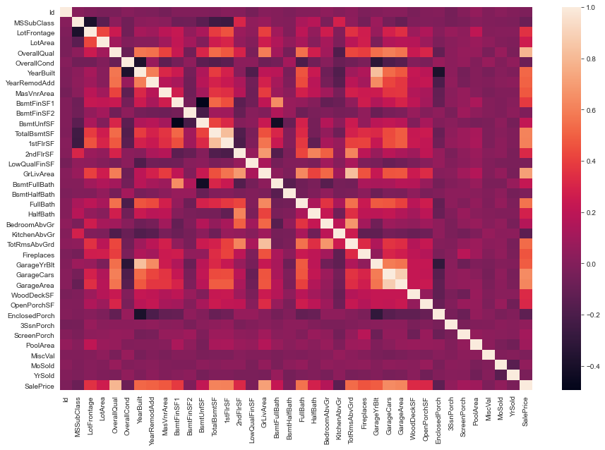

```python
df_corr = train_df.corr()
plt.figure(figsize=(15,10))
sns.heatmap(df_corr)
a_corrlist = df_corr['SalePrice'].sort_values(ascending=False)
a_corrlist[1:5]
```

## -- Fourth section:

As we can see below, there is minor changes in corr values for the first 4 candidates. This situation has also happened for all other numberical values too(recognized by printing both series).

### The reason is that by replacing saleprice with log of saleprice, non linear relationships are converted to linear ones and thus makes dependencies a bit more clear.

```
OverallQual    0.817184
GrLivArea      0.700927
GarageCars     0.680625
GarageArea     0.650888
Name: SalePrice, dtype: float64
```

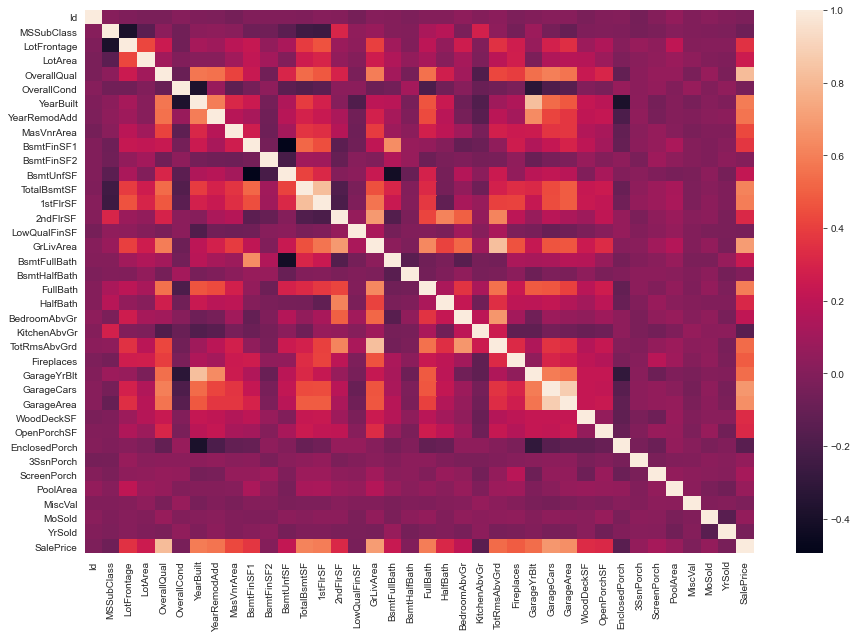

```python
temp_train_df = train_df
temp_train_df['SalePrice'] = np.log2(temp_train_df['SalePrice'])
tdf_corr = temp_train_df.corr()
plt.figure(figsize=(15,10))
sns.heatmap(tdf_corr)
t_corrlist = tdf_corr['SalePrice'].sort_values(ascending=False)
t_corrlist[1:5]
```

## -- Fifth section:

No, the problem with that approach is that it totally ignores the fact that columns could also be non-numeric. As shown below, there are at least a dozen columns containing categorical values (denoted by type 'Object' or 'O'). Obviously we should use a different method to calculated correlation of these columns and **SalePrice** column.

```python
g = train_df.columns.to_series().groupby(train_df.dtypes).groups
column_tuple = list(g.items())[-1]
column_tuple
```

```
(dtype('O'),
 Index(['MSZoning', 'Street', 'Alley', 'LotShape', 'LandContour', 'Utilities',
        'LotConfig', 'LandSlope', 'Neighborhood', 'Condition1', 'Condition2',
        'BldgType', 'HouseStyle', 'RoofStyle', 'RoofMatl', 'Exterior1st',
        'Exterior2nd', 'MasVnrType', 'ExterQual', 'ExterCond', 'Foundation',
        'BsmtQual', 'BsmtCond', 'BsmtExposure', 'BsmtFinType1', 'BsmtFinType2',
        'Heating', 'HeatingQC', 'CentralAir', 'Electrical', 'KitchenQual',
        'Functional', 'FireplaceQu', 'GarageType', 'GarageFinish', 'GarageQual',
        'GarageCond', 'PavedDrive', 'PoolQC', 'Fence', 'MiscFeature',
        'SaleType', 'SaleCondition'],
       dtype='object'))
```

## -- Sixth section:

For the first set of plots, scatter plot is used alogside regression line of each plot. As we can see, OverallQuall and GarageCars sections have got limited variety and are more straight forward than GrLivArea and GarageArea which are more diverse in terms of values. As for the second set of plots, hexbin plot is used. A Hexbin plot is useful to represent the relationship of 2 numerical variables when you have a lot of data point. Instead of overlapping, the plotting window is split in several hexbins,and the number of points per hexbin is counted. The color denotes this number of points.

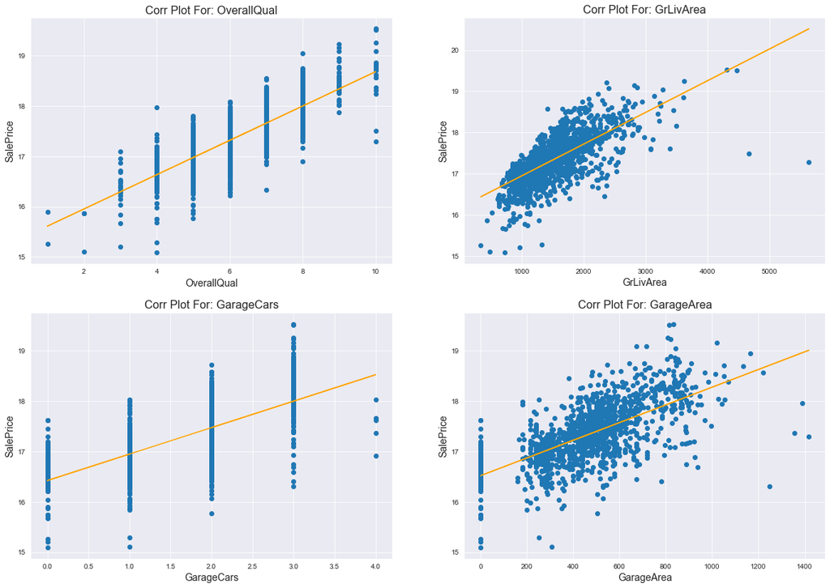

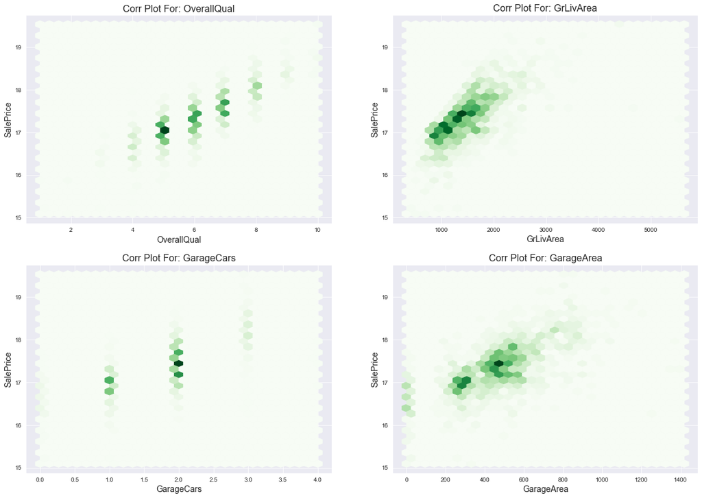

```python
plt.figure(figsize=(20, 14))
feature_list = ['OverallQual', 'GrLivArea', 'GarageCars', 'GarageArea']
for i in range(len(feature_list)):
    plt.subplot(2,2,i+1)
    x,y = train_df[feature_list[i]],  train_df['SalePrice']
    m, b = np.polyfit(x, y, 1)
    plt.scatter(x,y)
    plt.plot(x, m*x + b, color="orange")
    plt.xlabel(feature_list[i], fontsize=14)
    plt.ylabel('SalePrice', fontsize=14)
    plt.title("Corr Plot For: " + feature_list[i], fontsize=16)

plt.figure(figsize=(20, 14))
for i in range(len(feature_list)):
    plt.subplot(2,2,i+1)
    x,y = train_df[feature_list[i]],  train_df['SalePrice']
    plt.hexbin(x,y, gridsize=30, cmap='Greens')
    plt.xlabel(feature_list[i], fontsize=14)
    plt.ylabel('SalePrice', fontsize=14)
    plt.title("Corr Plot For: " + feature_list[i], fontsize=16)
```

## -- Seventh section:

### BldgType, KitchenQual, ExterQual, HeatingQC

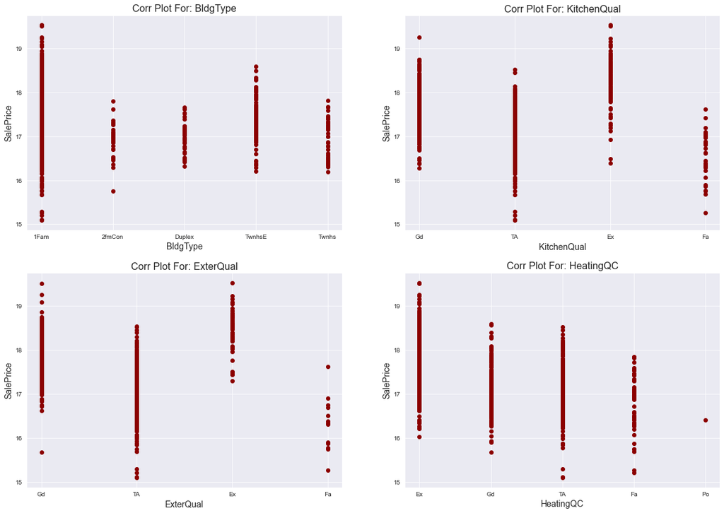

```python
plt.figure(figsize=(20, 14))
feature_list = ['BldgType', 'KitchenQual', 'ExterQual', 'HeatingQC']
for i in range(len(feature_list)):
    plt.subplot(2,2,i+1)
    x,y = train_df[feature_list[i]],  train_df['SalePrice']
    plt.scatter(x,y, color='darkred')
    plt.xlabel(feature_list[i], fontsize=14)
    plt.ylabel('SalePrice', fontsize=14)
    plt.title("Corr Plot For: " + feature_list[i], fontsize=16)
```

# Phase 1:

## -- First section:

### Numeric columns missing val handling:

1. Constant value: Replace it with a constant value. Typically, this is used in discussion with the domain expert for the data we are dealing with.

2. Mean or median:Replace it with the mean or the median. This is a decent approach especially when the data size small, but it does add bias.

3. Based on other columns:Replace it with values by making use of information from other columns.

### Categorical columns missing val handling:

1. Constant value: Replace it with a constant value or the most popular category. This is a good approach especially when the data size is small — but it does add **bias**.

2. Classification:One can also create a classification model.By using prediction methods we can fill in the missing values based on information and processing on other columns.

3. Unknown:The most common and popular approach is to model the missing value in a categorical column as a new category called “Unknown.” **We use this method for most our of categorical columns**

## -- Second section:

There are 19 columns that contain at least one nan value. According to section two of the last phase, these features are tops in missing data ranking:

### Non-numeric columns:

1. PoolQC: Pool quality, **99.52% missing** Please note that as described in data_description file, missing values in this column shows that there is no pool in the corresponding house so this column should be kept!Also, null values represent a meaningful fact so filling as 'nonexist' category will suffice!

2. MiscFeature and MiscVal: Miscellaneous feature not covered in other categories, **96.30% missing** Please note that as described in data_description file, missing values in this column shows that there is no other feature (like second elevator or shed) in the corresponding house so this column should be kept! Also, null values represent a meaningful fact so filling as 'nonexist' category will suffice!

3. Alley: Type of alley access to property **93.76% missing** Please note that as described in data_description file, missing values in this column shows that there is no alley access for the corresponding house so this column should be kept! Also, null values represent a meaningful fact so filling as 'nonexist' category will suffice!

4. Fence: Fence quality. **80.75% missing** Please note that as described in data_description file, missing values in this column shows that there is no fence for the corresponding house so this column should be kept! Also, null values represent a meaningful fact so filling as 'nonexist' category will suffice!

5. FireplaceQu: Fireplace quality. **47.26% missing** Please note that as described in data_description file, missing values in this column shows that there is no fireplace for the corresponding house so this column should be kept! Also, null values represent a meaningful fact so filling as 'nonexist' category will suffice!

### Numeric columns:

1. LotFrontage: Linear feet of street connected to property, **17.73% missing** Since this column is a numeric column, null values represent lack of data and also each value is unique to it's corresponding house so conventional methods of filling (such as ffill,bfill, using mode or mean) does not apply here. so this column should be removed!

2. GarageYrBlt: Year garage was built, **5.54% missing** Since this column is a numeric column, null values represent lack of data and also each value is unique to it's corresponding house so conventional methods of filling (such as ffill,bfill, using mode or mean) does not apply here. But only 5 percent of data is missing so this column should be kept!. We will assume value from **YearBuilt** for this column to fill missing values.

All other numeric columns are sufficiently filled with data.

```python
numerics = ['int16', 'int32', 'int64', 'float16', 'float32', 'float64']
train_df = pd.read_csv('train.csv')
train_df.columns[train_df.isna().any()].tolist()
numeric_columns = train_df.select_dtypes(include=numerics).columns

print(a.sort_values(ascending=False)[0:5])
print(a[a.index.isin(numeric_columns)].sort_values(ascending=False)[0:5])

train_df.update(train_df[['PoolQC','MiscFeature','Alley', 'Fence', 'FireplaceQu', 'BsmtFinType1',
             'GarageFinish', 'GarageType', 'GarageCond', 'GarageQual', 'BsmtFinType2', 'BsmtCond',
                         'BsmtExposure', 'BsmtQual']].fillna('nonexist'))
del train_df['LotFrontage']
train_df['GarageYrBlt'] = train_df['GarageYrBlt'].fillna(train_df['YearBuilt'])
train_df['MasVnrArea'] = train_df['MasVnrArea'].fillna(0)
```

```
PoolQC         99.520548
MiscFeature    96.301370
Alley          93.767123
Fence          80.753425
FireplaceQu    47.260274
dtype: float64
LotFrontage     17.739726
GarageYrBlt      5.547945
MasVnrArea       0.547945
BsmtFinSF1       0.000000
LowQualFinSF     0.000000
dtype: float64
```

## -- Third section:

1. Normalization: Similarly, the goal of normalization is to change the values of numeric columns in the dataset to a common scale, without distorting differences in the ranges of values. For machine learning, every dataset does not require normalization. It is required only when features have different ranges. For example, consider a data set containing two features, age, and income(x2). Where age ranges from 0–100, while income ranges from 0–100,000 and higher. Income is about 1,000 times larger than age. So, these two features are in very different ranges.

2. Standardization: Standardizing the features around the center and 0 with a standard deviation of 1 is important when we compare measurements that have different units. Variables that are measured at different scales do not contribute equally to the analysis and might end up creating a bais.

#### Columns that can not be changed because they don't have a big range or their alternates will ruin their domain meaning: Id / MSSubClass / Fireplaces / GarageYrBlt / YrSold / YearRemodAdd / OverallCond / OverallCond / YearBuilt / SalePrice / GarageCars

#### Other columns are mainly ascribed to area or count of something. These values must be left intact too. So no normalization or standardization is required.

```
Index(['Id', 'MSSubClass', 'LotArea', 'OverallQual', 'OverallCond',
       'YearBuilt', 'YearRemodAdd', 'MasVnrArea', 'BsmtFinSF1', 'BsmtFinSF2',
       'BsmtUnfSF', 'TotalBsmtSF', '1stFlrSF', '2ndFlrSF', 'LowQualFinSF',
       'GrLivArea', 'BsmtFullBath', 'BsmtHalfBath', 'FullBath', 'HalfBath',
       'BedroomAbvGr', 'KitchenAbvGr', 'TotRmsAbvGrd', 'Fireplaces',
       'GarageYrBlt', 'GarageCars', 'GarageArea', 'WoodDeckSF', 'OpenPorchSF',
       'EnclosedPorch', '3SsnPorch', 'ScreenPorch', 'PoolArea', 'MiscVal',
       'MoSold', 'YrSold', 'SalePrice'],
      dtype='object')
```

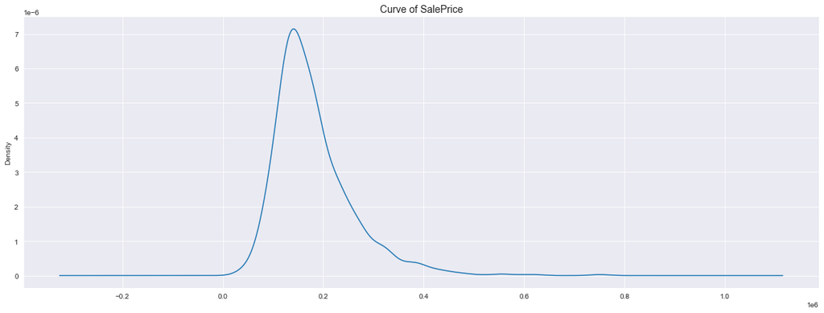

```python
plt.figure(figsize=(20, 7))
train_df['SalePrice'].plot.kde()
plt.title("Curve of SalePrice", fontsize=14)

numeric_df = train_df.select_dtypes(include=numerics)
numeric_df.columns
```

## -- Fourth section:No, each one has to be handled in its own way.

1. Binary Feature Encoding: Binary features are those with only two possible values. we can use Panda’s replace() to encode them.

2. Ordinal Feature Encoding: Ordinal features are those with some order associated with them. We can tell from the sample of ordinal features below these features have an order that may be important.For ordinal features, we use integer encoding. To integer encode our data we simply convert labels to integer values.We can label encode data with **Sklearn’s LabelEncoder()**. While using LabelEncoder() is very quick and easy, it may not be the best choice here: the order of our encoding is not exactly right. Also, we had to handle our null values before being able to use it. **Panda’s map()** substitutes each value with another specified value, similar to replace() that we used above. We have four types of ordinal columns. Each type has been handled separately.

3. Nominal Features: Nominal features are categorical features that have no numerical importance. Order does not matter.**One-hot encoding** is a better technique when order doesn’t matter.Despite the different names, the basic strategy is to convert each category value into a new column and assigns a 1 or 0 (True/False) value to the column. This has the benefit of not weighting a value improperly but does have the downside of adding more columns to the data set.

```python
def ordinal_encode():
    ord1_dict = {"nonexist":0, "Po":1, "Fa":2, "TA":3, "Gd":4, "Ex":5}
    ordinal_columns1 = [
        'ExterQual', 'ExterCond', 'BsmtQual', 'BsmtCond', 'HeatingQC',
        'KitchenQual', 'FireplaceQu', 'GarageQual', 'GarageCond', 'PoolQC']
    for i in ordinal_columns1:
        train_df[i] = train_df[i].map(ord1_dict)

    ord2_dict = {"N":0, "Y":1}
    ordinal_columns2 = ['CentralAir']
    for i in ordinal_columns2:
        train_df[i] = train_df[i].map(ord2_dict)

    ord3_dict = {"AllPub":4, "NoSewr":3, "NoSeWa":2, "ELO":1}
    ordinal_columns3 = ['Utilities']
    for i in ordinal_columns3:
        train_df[i] = train_df[i].map(ord3_dict)

    ord4_dict = {"nonexist":0, "Unf":1, "LwQ":2, "Rec":3, "BLQ":4, "ALQ":5, "GLQ":6}
    ordinal_columns4 = ['BsmtFinType1', 'BsmtFinType2']
    for i in ordinal_columns4:
        train_df[i] = train_df[i].map(ord4_dict)

    ord5_dict = {"nonexist":0, "No":1, "Mn":2, "Av":3, "Gd":4}
    ordinal_columns5 = ['BsmtExposure']
    for i in ordinal_columns5:
        train_df[i] = train_df[i].map(ord5_dict)


nominal_columns = ['Foundation', 'MSZoning', 'Alley', 'LotShape','LandContour', 'Street',
                   'LotConfig', 'Neighborhood', 'HouseStyle', 'RoofMatl', 'BldgType', 'LandSlope',
                    'Condition1', 'RoofStyle', 'Condition2', 'Exterior1st', 'Exterior2nd', 'MasVnrType',
                   'Heating', 'Electrical', 'Functional', 'GarageType', 'SaleType', 'SaleCondition',
                  'GarageFinish', 'PavedDrive', 'MiscFeature', 'Fence']

train_df = pd.get_dummies(train_df, columns = nominal_columns, drop_first = True)


ordinal_encode()
train_df
```

|  | Id | MSSubClass | LotArea | Utilities | OverallQual | OverallCond | YearBuilt | YearRemodAdd | MasVnrArea | ExterQual | ... | PavedDrive_P | PavedDrive_Y | MiscFeature_Othr | MiscFeature_Shed | MiscFeature_TenC | MiscFeature_nonexist | Fence_GdWo | Fence_MnPrv | Fence_MnWw | Fence_nonexist |
| --- | --- | --- | --- | --- | --- | --- | --- | --- | --- | --- | --- | --- | --- | --- | --- | --- | --- | --- | --- | --- | --- |
| 0 | 1 | 60 | 8450 | 4 | 7 | 5 | 2003 | 2003 | 196.0 | 4 | ... | 0 | 1 | 0 | 0 | 0 | 1 | 0 | 0 | 0 | 1 |
| 1 | 2 | 20 | 9600 | 4 | 6 | 8 | 1976 | 1976 | 0.0 | 3 | ... | 0 | 1 | 0 | 0 | 0 | 1 | 0 | 0 | 0 | 1 |
| 2 | 3 | 60 | 11250 | 4 | 7 | 5 | 2001 | 2002 | 162.0 | 4 | ... | 0 | 1 | 0 | 0 | 0 | 1 | 0 | 0 | 0 | 1 |
| 3 | 4 | 70 | 9550 | 4 | 7 | 5 | 1915 | 1970 | 0.0 | 3 | ... | 0 | 1 | 0 | 0 | 0 | 1 | 0 | 0 | 0 | 1 |
| 4 | 5 | 60 | 14260 | 4 | 8 | 5 | 2000 | 2000 | 350.0 | 4 | ... | 0 | 1 | 0 | 0 | 0 | 1 | 0 | 0 | 0 | 1 |
| ... | ... | ... | ... | ... | ... | ... | ... | ... | ... | ... | ... | ... | ... | ... | ... | ... | ... | ... | ... | ... | ... |
| 1455 | 1456 | 60 | 7917 | 4 | 6 | 5 | 1999 | 2000 | 0.0 | 3 | ... | 0 | 1 | 0 | 0 | 0 | 1 | 0 | 0 | 0 | 1 |
| 1456 | 1457 | 20 | 13175 | 4 | 6 | 6 | 1978 | 1988 | 119.0 | 3 | ... | 0 | 1 | 0 | 0 | 0 | 1 | 0 | 1 | 0 | 0 |
| 1457 | 1458 | 70 | 9042 | 4 | 7 | 9 | 1941 | 2006 | 0.0 | 5 | ... | 0 | 1 | 0 | 1 | 0 | 0 | 0 | 0 | 0 | 0 |
| 1458 | 1459 | 20 | 9717 | 4 | 5 | 6 | 1950 | 1996 | 0.0 | 3 | ... | 0 | 1 | 0 | 0 | 0 | 1 | 0 | 0 | 0 | 1 |
| 1459 | 1460 | 20 | 9937 | 4 | 5 | 6 | 1965 | 1965 | 0.0 | 4 | ... | 0 | 1 | 0 | 0 | 0 | 1 | 0 | 0 | 0 | 1 |

1460 rows × 217 columns

## -- Fifth section:

Those columns which their corr value (to saleprice!) is less than 25 percent can be deleted. (25 percent positive or negative). Categorical columns can now be checked in corr function since we have encoded them in section 4.

```python
df_corr = train_df.corr()
a_corrlist = df_corr['SalePrice'].sort_values(ascending=False)
strong_columns = a_corrlist[abs(a_corrlist) >= 0.25].index.to_list()

train_df = train_df[strong_columns]
```

## -- Sixth section:

Data is split as per a split ratio which is highly dependent on the type of model we are building and the dataset itself. If our dataset and model are such that a lot of training is required, then we use a larger chunk of the data just for training purposes (usually the case) — For instance, training on **textual data, image data, or video data** usually involves thousands of features! With less training data, your parameter estimates have greater variance. With less testing data, your performance statistic will have greater variance. Broadly speaking you should be concerned with dividing data such that neither variance is too high, which is more to do with the absolute number of instances in each category rather than the percentage.The following data partitioning methods have been suggested in several literatures in the field of Machine learning/ Pattern recognition:

a). 70% of the entire Dataset for training (Training data)

b). 15% of the entire Dataset for validation (Validation data)

c). 15% of the entire Dataset for testing (Testing data)

Alternatively, you can partition the Noisy Dataset into two part:

a). 75% of the entire Dataset for training (Training data)

b). 25% of the entire Dataset for testing (Testing data)

Also, it is recommended to use **some sort of random method of** choosing and spliting dataset in order to prevent unnecessary biases. Bias will probably cause prediction phase to have unrealiable results for each run.

# Phase 2:

## -- First and Second section:

### linear regression:

Linear regression is a statistical model that examines the linear relationship between two (Simple Linear Regression ) or more (Multiple Linear Regression) variables — a dependent variable and independent variable(s). Linear relationship basically means that when one (or more) independent variables increases (or decreases), the dependent variable increases (or decreases) too. There are two main ways to perform linear regression in Python — with Statsmodels and scikit-learn. Explanation of some used methods:

**train_test_split:** Split arrays or matrices into random train and test subsets. Test size is set to be 0.2 of total dataframe. Random state controls the shuffling applied to the data before applying the split. Pass an int for reproducible output across multiple function calls.For optimum situation and since we only have one parameter to optimize, A loop is used to find best random_state number.

**reshape:** Gives a new shape to an array without changing its data. Needed to make a 2d vector out of y_train, y_test and predictions.

#### As you can see at the end of this block, there are 63 random_state values that are qualified.

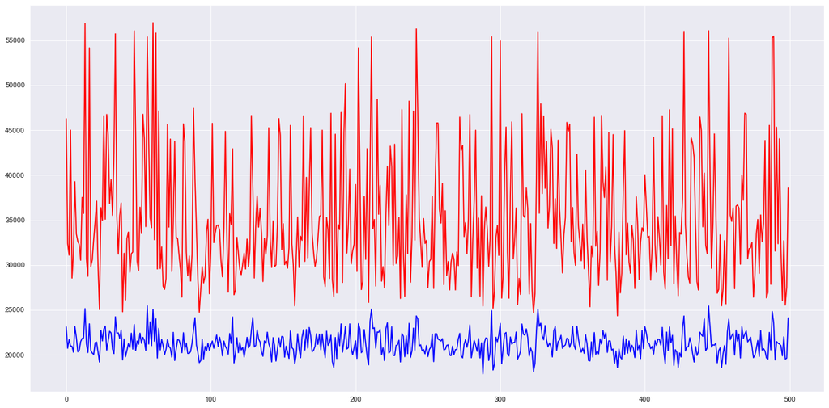

|  | mae | rmse | random_value |
| --- | --- | --- | --- |
| 381 | 18567.591371 | 24345.858586 | 381 |
| 323 | 18166.185388 | 24702.235576 | 323 |
| 92 | 19127.176779 | 24737.163995 | 92 |
| 39 | 19424.948015 | 24785.058438 | 39 |
| 23 | 19192.852554 | 25037.353790 | 23 |
| ... | ... | ... | ... |
| 63 | 19628.738840 | 29548.967221 | 63 |
| 142 | 19209.093554 | 29723.740788 | 142 |
| 292 | 19363.829672 | 29843.938351 | 292 |
| 226 | 19960.998922 | 29949.412169 | 226 |
| 145 | 19300.471304 | 29996.300590 | 145 |

63 rows × 3 columns

```python
mae_results = []
rmse_results = []
x_value = [x for x in range(500)]
for i in range(500):
    X_train, X_test, y_train, y_test = train_test_split(train_df.drop('SalePrice', axis=1),
                                                        train_df['SalePrice'], test_size=0.2, random_state=i)
    y_train= y_train.values.reshape(-1,1)
    y_test= y_test.values.reshape(-1,1)
    lm = LinearRegression()
    lm.fit(X_train,y_train)
    predictions = lm.predict(X_test)
    predictions= predictions.reshape(-1,1)
    mae_results.append(metrics.mean_absolute_error(y_test, predictions))
    rmse_results.append(np.sqrt(metrics.mean_squared_error(y_test, predictions)))

plt.figure(figsize=(20, 10))
plt.plot(x_value,mae_results, c='blue')
plt.plot(x_value,rmse_results, c='red')
plt.show()
linear_df = pd.DataFrame({'mae': mae_results, 'rmse': rmse_results, 'random_value': x_value})
linear_df[(linear_df['mae'] <= 20000) & (linear_df['rmse'] <= 30000)].sort_values(by=['rmse'])
```

### Knn:

k-Nearest-Neighbors (k-NN) is a supervised machine learning model. Supervised learning is when a model learns from data that is already labeled. k-NN models work by taking a data point and looking at the ‘k’ closest labeled data points. The data point is then assigned the label of the majority of the ‘k’ closest points. For example, if k = 5, and 3 of points are ‘green’ and 2 are ‘red’, then the data point in question would be labeled ‘green’, since ‘green’ is the majority. This makes training faster and testing phase slower and costlier. Costly testing phase means time and memory. In the worst case, KNN needs more time to scan all data points and scanning all data points will require more memory for storing training data. Explanation of some used methods:

**train_test_split:** Split arrays or matrices into random train and test subsets. Test size is set to be 0.2 of total dataframe. Random state controls the shuffling applied to the data before applying the split. Pass an int for reproducible output across multiple function calls.For optimum situation and since we only have one parameter to optimize, A loop is used to find best random_state number.

#### Note that there are two parameters to consider here. First one being random_state and second being n_neighbors. For each n_neighbor value, 100 random_state values has been analysed and their best(min mae/rmse) is chosen to represent result of that n_neighbor.

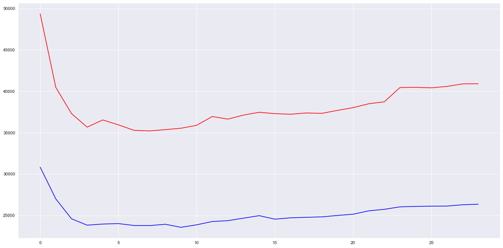

```
Best Results:
MAE:  23575.522602739726
RMSE:  35534.7658834795
N_neighbors:  9
Random_state:  97
```

```python
mae_results = []
rmse_results = []
min_indexs = []
x_value = [x for x in range(29)]
for i in range(1,30):
    mae_temp = []
    rmse_temp = []
    for j in range(100):
        X_train, X_test, y_train, y_test = train_test_split(train_df.drop('SalePrice', axis=1),
                                                        train_df['SalePrice'], test_size=0.2, random_state=j)
        knn = KNeighborsRegressor(n_neighbors=i)
        knn.fit(X_train, y_train)
        predictions = knn.predict(X_test)
        mae_temp.append(metrics.mean_absolute_error(y_test, predictions))
        rmse_temp.append(np.sqrt(metrics.mean_squared_error(y_test, predictions)))

    min_index = mae_temp.index(min(mae_temp))
    min_indexs.append(min_index)
    mae_results.append(mae_temp[min_index])
    rmse_results.append(rmse_temp[min_index])


plt.figure(figsize=(20, 10))
plt.plot(x_value,mae_results, c='blue')
plt.plot(x_value,rmse_results, c='red')
plt.show()

super_min_idx = mae_results.index(min(mae_results))
print("Best Results:")
print("MAE: ", mae_results[super_min_idx])
print("RMSE: ", rmse_results[super_min_idx])
print("N_neighbors: ", super_min_idx)
print("Random_state: ", min_indexs[super_min_idx])
```

### Decison tree:

Decision Tree is one of the popular and most widely used Machine Learning Algorithms because of its robustness to noise, tolerance against missing information, handling of irrelevant, redundant predictive attribute values, low computational cost, interpretability, fast run time and robust predictors. Explanation of some used methods:

**train_test_split:** Split arrays or matrices into random train and test subsets. Test size is set to be 0.2 of total dataframe. Random state controls the shuffling applied to the data before applying the split. Pass an int for reproducible output across multiple function calls.For optimum situation and since we only have one parameter to optimize, A loop is used to find best random_state number.

**max_depth:** The maximum depth of the tree. If None, then nodes are expanded until all leaves are pure or until all leaves contain less than min_samples_split samples. The theoretical maximum depth a decision tree can achieve is one less than the number of training samples, but no algorithm will let you reach this point for obvious reasons, one big reason being overfitting.

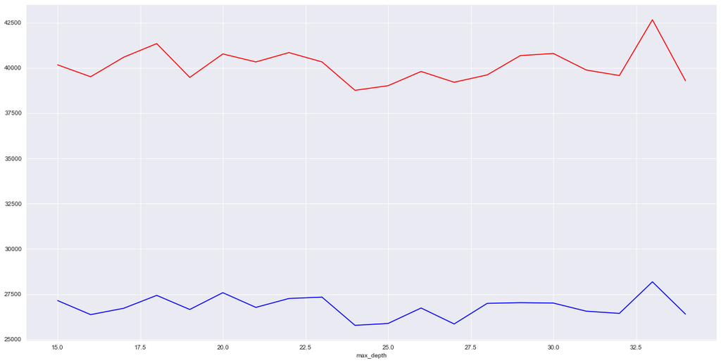

```
Best Results:
MAE:  25775.102739726026
RMSE:  38758.26009072484
Max_depth:  24
Random_state:  20
```

```python
mae_results = []
rmse_results = []
min_indexs = []
x_value = [x for x in range(15,35)]
for i in range(15,35):
    for j in range(20,70):
        mae_temp = []
        rmse_temp = []
        X_train, X_test, y_train, y_test = train_test_split(train_df.drop('SalePrice', axis=1),
                                                                train_df['SalePrice'], test_size=0.2, random_state=j)
        classifier = DecisionTreeRegressor(max_depth= i)
        classifier.fit(X_train, y_train)
        predictions = classifier.predict(X_test)
        mae_temp.append(metrics.mean_absolute_error(y_test, predictions))
        rmse_temp.append(np.sqrt(metrics.mean_squared_error(y_test, predictions)))

    min_index = mae_temp.index(min(mae_temp))
    min_indexs.append(min_index)
    mae_results.append(mae_temp[min_index])
    rmse_results.append(rmse_temp[min_index])

plt.figure(figsize=(20, 10))
plt.plot(x_value,mae_results, c='blue')
plt.plot(x_value,rmse_results, c='red')
plt.xlabel("max_depth")
plt.show()
super_min_idx = mae_results.index(min(mae_results))
print("Best Results:")
print("MAE: ", mae_results[super_min_idx])
print("RMSE: ", rmse_results[super_min_idx])
print("Max_depth: ", super_min_idx + 15)
print("Random_state: ", min_indexs[super_min_idx] + 20)
```

## -- Third section:

**Overfitting** is the case where the overall cost is really small, but the generalization of the model is unreliable. This is due to the model learning “too much” from the training data set.

**Underfitting** is the case where the model has “ not learned enough” from the training data, resulting in low generalization and unreliable predictions.

#### Overfitting is when the model’s error on the training set (i.e. during training) is very low but then, the model’s error on the test set (i.e. unseen samples) is large!. Underfitting is when the model’s error on both the training and test sets (i.e. during training and testing) is very high.

### Linear Regression:

#### There is only 13 percent decrease in accuracy from train to test. So this model is fine.

```python
X_train, X_test, y_train, y_test = train_test_split(train_df.drop('SalePrice', axis=1),
                                                        train_df['SalePrice'], test_size=0.2, random_state=381)

lm = LinearRegression()
lm.fit(X_train,y_train)
y_train_data_pred = lm.predict(X_train)
y_test_data_pred = lm.predict(X_test)
mae_train = metrics.mean_absolute_error(y_train, y_train_data_pred)
mae_test = metrics.mean_absolute_error(y_test, y_test_data_pred)

print("Train to Test mae difference: -", mae_train / mae_test - 1)
```

```
Train to Test mae difference: - 0.1355542887122485
```

### Knn:

#### There is only 14 percent decrease in accuracy from train to test. So this model is fine.

```python
X_train, X_test, y_train, y_test = train_test_split(train_df.drop('SalePrice', axis=1),
                                                        train_df['SalePrice'], test_size=0.2, random_state=97)

knn = KNeighborsRegressor(n_neighbors=9)
knn.fit(X_train, y_train)
y_train_data_pred = knn.predict(X_train)
y_test_data_pred = knn.predict(X_test)
mae_train = metrics.mean_absolute_error(y_train, y_train_data_pred)
mae_test = metrics.mean_absolute_error(y_test, y_test_data_pred)

print("Train to Test mae difference: -", mae_train / mae_test - 1)
```

```
Train to Test mae difference: - 0.140517562455716
```

### Decision tree:

```python
X_train, X_test, y_train, y_test = train_test_split(train_df.drop('SalePrice', axis=1),
                                                        train_df['SalePrice'], test_size=0.2, random_state=20)

classifier = DecisionTreeRegressor(max_depth= 22)
classifier.fit(X_train, y_train)
y_train_data_pred = classifier.predict(X_train)
y_test_data_pred = classifier.predict(X_test)
mae_train = metrics.mean_absolute_error(y_train, y_train_data_pred)
mae_test = metrics.mean_absolute_error(y_test, y_test_data_pred)

print("Train to Test mae difference: ", mae_train / mae_test - 1)
```

```
Train to Test mae difference:  -0.9997487847546244
```

## -- Fourth section:

1. Deleting LotFrontage: As stated above, this column has got about 17% missing data. Also, there is no other good ways to fill in the blanks for this column. Furthermore, by filling this column with mean, mode or zero, precision of models will slightly decrease(less that $100). So it is better to remove this column from dataframe before training prediction models.

2. Label Encoding: This is a crucial part of modeling. Without it, we either should **ignore those columns** or **use one-hot** instead. Ignoring would result in a seroius loss of data that would increase error margin(by at least 20 percent!). Using one-hot has it's own problems. one-hotting all categorical columns would increase the count of coulmns to more than 200. This might result in providing too much data that might not be useful or even decieving.

3. Filling GarageYrBlt: We have two options here. Either delete this column or fill it with some data. Deleting it would result in an accuracy loss of about 2 percent. Filling it with zeros will reduce accuracy too.(about 1 percent). So best way is to fill it up using the YearBuilt value.

3. One-hot columns: There is an option to delete those catagorical columns that can not be label encoded. By using this method, some results in across all three models will improve will some others will be weakend. On average, there is more loss that gain here so it is better to one-hot encode them and use them for prediction.

# Phase 3:

## -- First section:

A random forest is a meta estimator that fits a number of classifying decision trees on various sub-samples of the dataset and uses averaging to improve the predictive accuracy and control over-fitting.

2. max_depth: The maximum depth of the tree. If None, then nodes are expanded until all leaves are pure or until all leaves contain less than min_samples_split samples. Values ranging form 10 to 30 have been tested for this parameter.

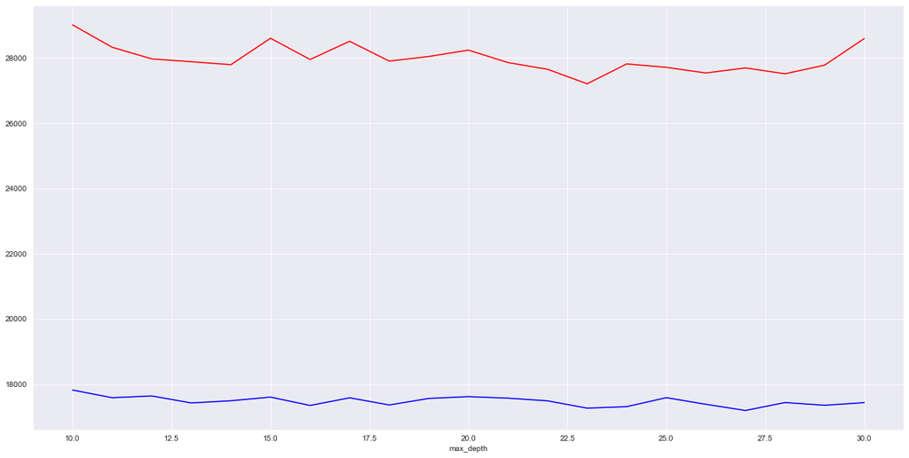

```
Best Results:
MAE:  17271.33897260274
RMSE:  27211.108199319006
Max_depth:  23
N_estomators:  100
```

```python
from sklearn.ensemble import RandomForestRegressor
mae_results = []
rmse_results = []
min_indexs = []
X_train, X_test, y_train, y_test = train_test_split(train_df.drop('SalePrice', axis=1),
                                                        train_df['SalePrice'], test_size=0.2, random_state=42)
depth_list = list(range(10,31))
est_list = [10,30,50,70,80,100]
for dp in depth_list:
    mae_temp = []
    rmse_temp = []
    for est in est_list:
        rf = RandomForestRegressor(n_estimators = est, max_depth = dp)
        rf.fit(X_train, y_train)
        predictions = rf.predict(X_test)
        mae_temp.append(metrics.mean_absolute_error(y_test, predictions))
        rmse_temp.append(np.sqrt(metrics.mean_squared_error(y_test, predictions)))

    min_index = mae_temp.index(min(mae_temp))
    min_indexs.append(min_index)
    mae_results.append(mae_temp[min_index])
    rmse_results.append(rmse_temp[min_index])

plt.figure(figsize=(20, 10))
plt.plot(depth_list,mae_results, c='blue')
plt.plot(depth_list,rmse_results, c='red')
plt.xlabel('max_depth')
plt.show()
super_min_idx = rmse_results.index(min(rmse_results))
print("Best Results:")
print("MAE: ", mae_results[super_min_idx])
print("RMSE: ", rmse_results[super_min_idx])
print("Max_depth: ", super_min_idx + 10)
print("N_estomators: ", est_list[min_indexs[super_min_idx]])
```

## -- Second section:

A voting regressor is an ensemble meta-estimator that fits several base regressors, each on the whole dataset. Then it averages the individual predictions to form a final prediction.

1. estimators: Invoking the fit method on the VotingRegressor will fit clones of those original estimators that will be stored in the class attribute self.estimators_.

2. weights: Sequence of weights (float or int) to weight the occurrences of predicted values before averaging. Uses uniform weights if None.

```python
from sklearn.ensemble import VotingRegressor
X_train, X_test, y_train, y_test = train_test_split(train_df.drop('SalePrice', axis=1),
                                                        train_df['SalePrice'], test_size=0.2, random_state=50)
min_mae = 100000
min_rmse = 100000
for j in range(50):
    lm = LinearRegression()
    lm.fit(X_train,y_train)
    knn = KNeighborsRegressor(n_neighbors=19)
    knn.fit(X_train, y_train)
    classifier = DecisionTreeRegressor(max_depth= 30)
    classifier.fit(X_train, y_train)

    voting_reg = VotingRegressor(estimators=[('Knn', knn), ('DTree', classifier), ('LogReg', lm)], weights = [2,5,3])
    voting_reg.fit(X_train,y_train)
    predictions = voting_reg.predict(X_test)
    mae = metrics.mean_absolute_error(y_test, predictions)
    if (mae < min_mae):
        min_mae = mae
        min_rmse = np.sqrt(metrics.mean_squared_error(y_test, predictions))

print("MAE: ", min_mae)
print("RMSE: ", min_rmse)
```

```
MAE:  18755.200829731493
RMSE:  29466.121257803155
```